# Predicting student performances with attributes

### Plotted data

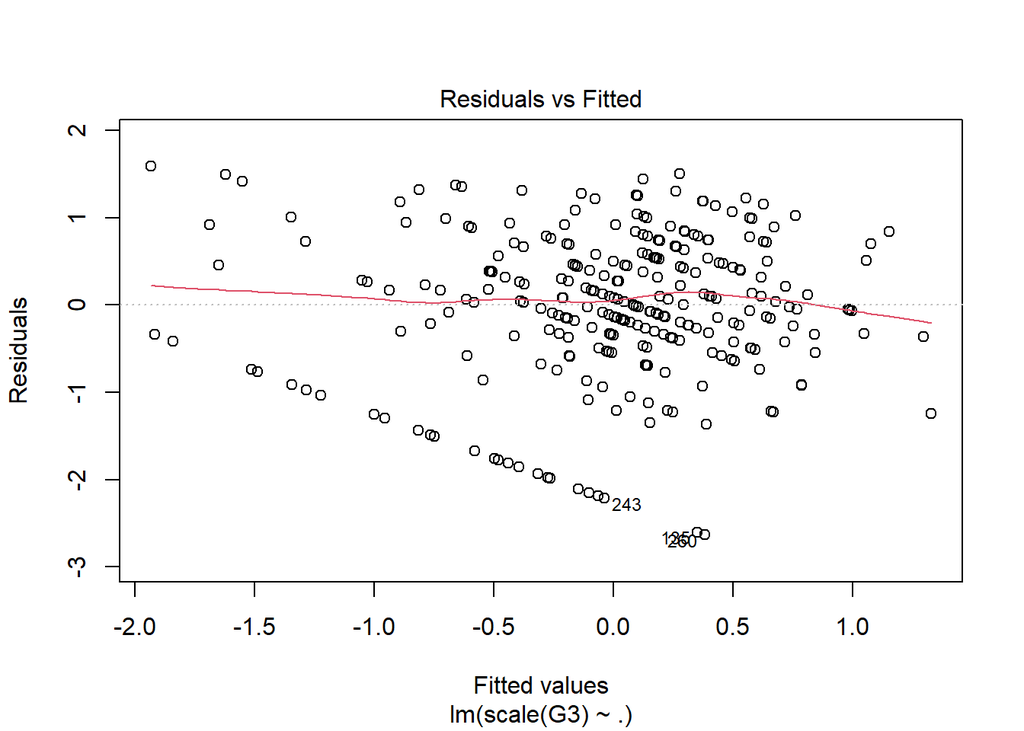

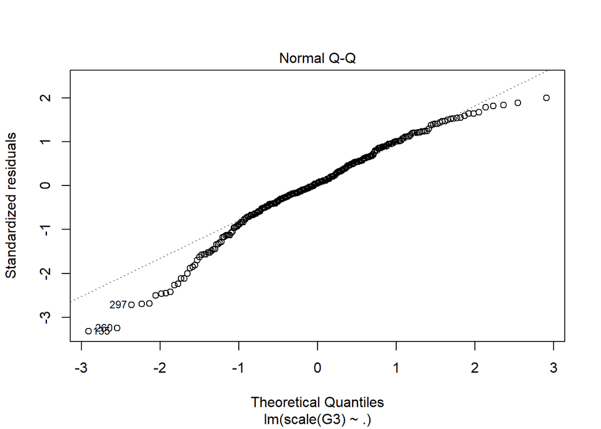

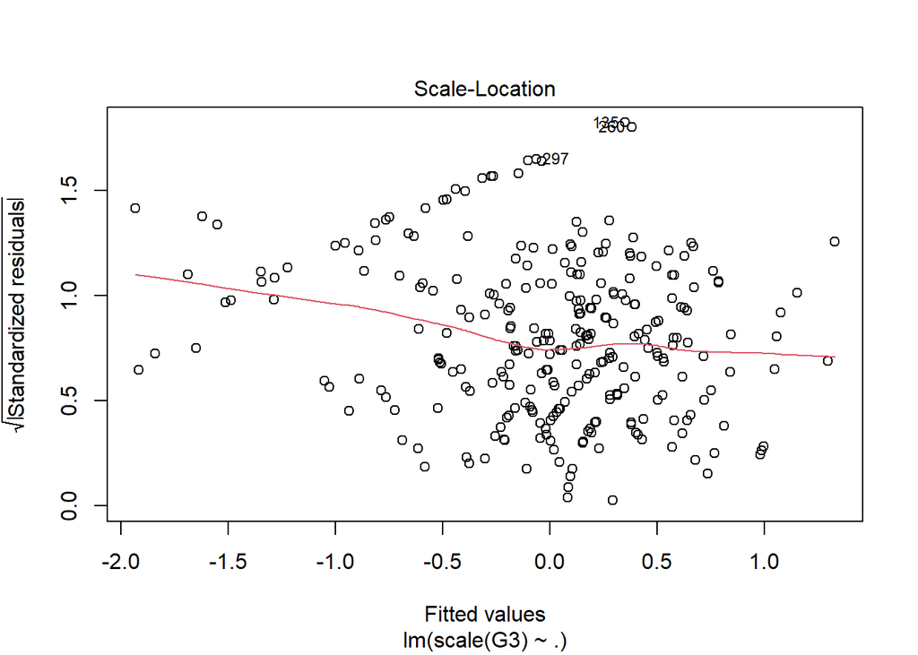

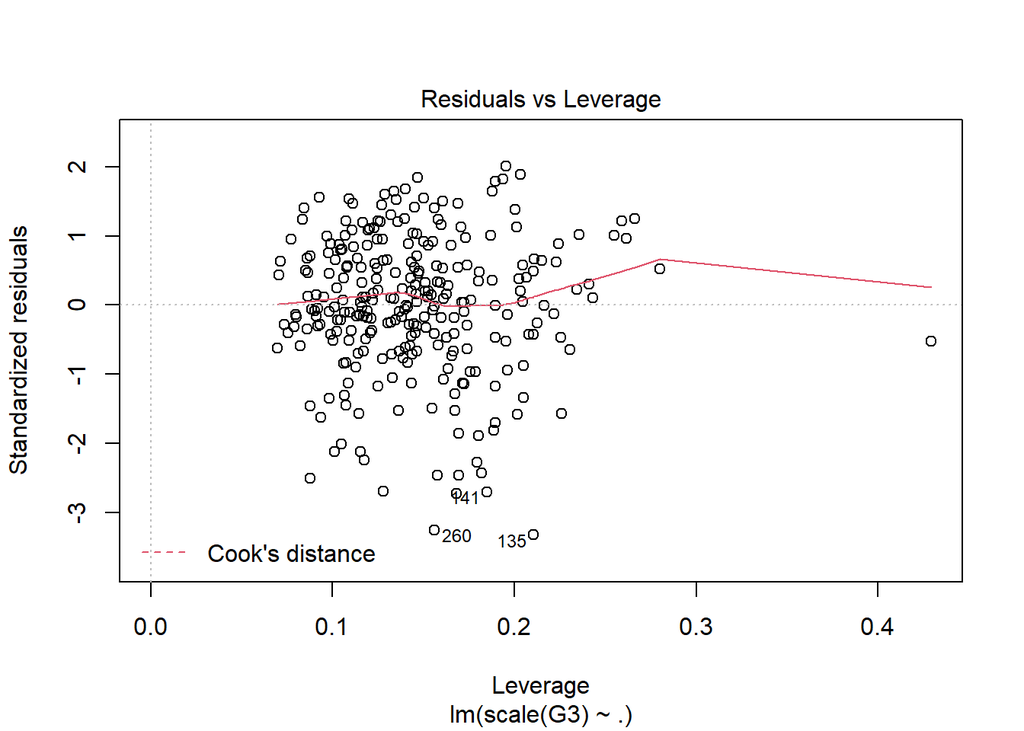

```r
# Plotted data
plot(m1)
```

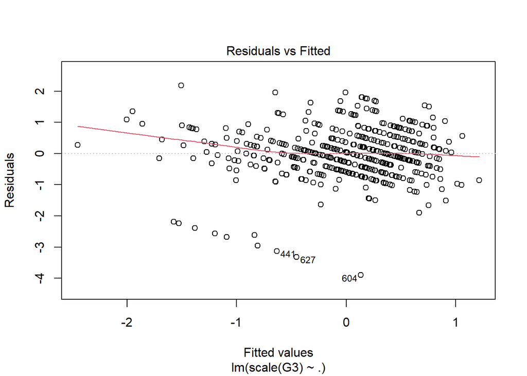

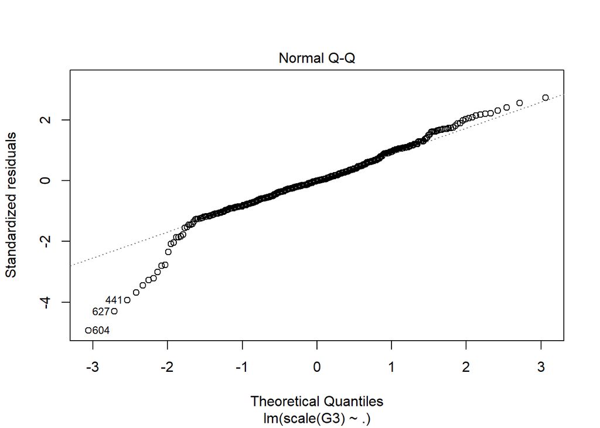

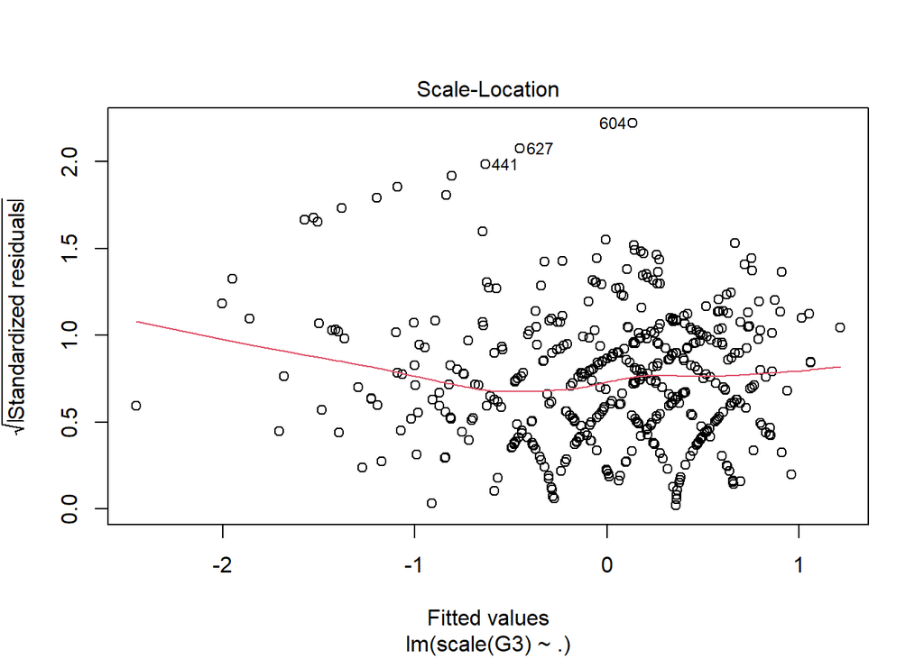

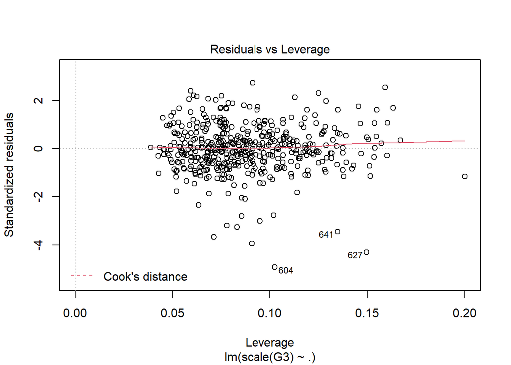

```r
plot(m2)
```

### Random Forest

Random Forest (RF) is a supervised learning algorithm used for classification and regression tasks. We can observe the Variable Importance Plots with RF to see the significant variables based on students who passed math and Portuguese. (Bhalla, 2015)

```r
# Random Forest
library(randomForest)

# Cleaning and creating new dataframe
newdata1.rf = school1
newdata1.rf$passed = factor(ifelse(school1$G3 >= 10, "yes", "no"))
newdata2.rf = school2
newdata2.rf$passed = factor(ifelse(school2$G3 >= 10, "yes", "no"))
newdata1.rf = subset(newdata1.rf, select = -c(G1,G2,G3))
newdata2.rf = subset(newdata2.rf, select = -c(G1,G2,G3))

# making RF with 100 trees
pre <- ncol(newdata1.rf)
passedmath_rf <- randomForest(passed~., data=newdata1.rf, mtry=pre, ntree=100)
passedportuguese_rf <- randomForest(passed~., data=newdata2.rf, mtry=pre, ntree=100)

importance(passedmath_rf)
```

```
##            MeanDecreaseGini
## school            0.8649265
## sex               3.0189109
## age               8.3644034
## address           1.3523935
## famsize           1.9011923
## Pstatus           0.9941314
## Medu              4.8954322
## Fedu              6.8803743
## Mjob             10.4839020
## Fjob              7.1916762
## reason            6.6636272
## guardian          4.4369410
## traveltime        4.0690519
## studytime         6.9992196
## failures         22.3614037
## schoolsup         4.2130681
## famsup            1.8696568
## paid              1.7504652
## activities        1.4143022
## nursery           1.9675330
## higher            1.3425988
## internet          1.9692244
## romantic          1.7520544
## famrel            6.6821874
## freetime          9.0805313
## goout            11.5930671
## Dalc              3.0772864
## Walc              7.0508054
## health            8.2373854
## absences         21.4592608
```

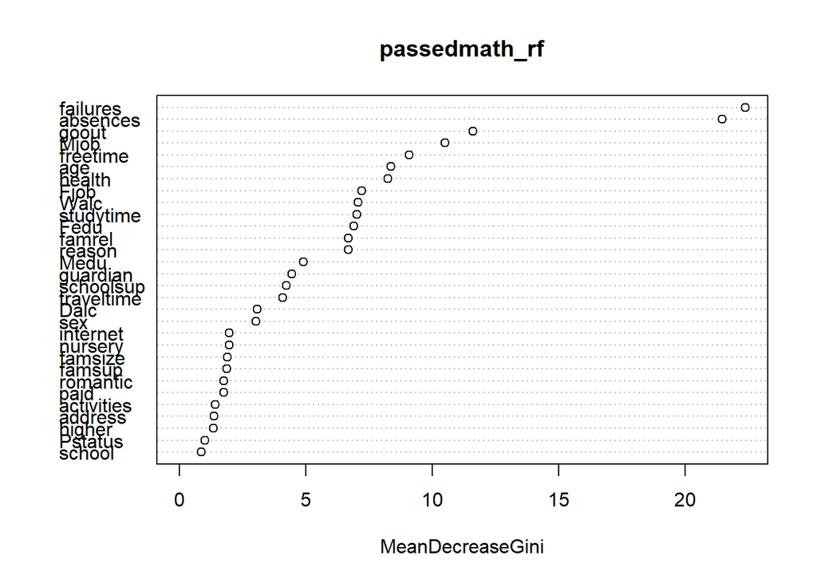

```r
varImpPlot(passedmath_rf)
```

```r
importance(passedportuguese_rf)
```

```
##            MeanDecreaseGini
## school            7.6979885
## sex               2.0303048
## age               5.7866996
## address           1.2115635
## famsize           3.6780696
## Pstatus           0.4811528
## Medu              4.7106471
## Fedu              5.8887606
## Mjob              6.2460825
## Fjob              4.2780834
## reason           10.0501329
## guardian          4.1225158
## traveltime        5.0561509
## studytime         3.7093507
## failures         26.9670464
## schoolsup         1.0980053
## famsup            1.5211129
## paid              2.2724300
## activities        1.8969210
## nursery           3.2710682
## higher            8.6610220
## internet          1.8867788
## romantic          2.0739413
## famrel            7.3229006
## freetime          7.1521834
## goout             7.2556843
## Dalc              7.3141559
## Walc              8.3455655
## health            6.3352306
## absences         12.2714252
```

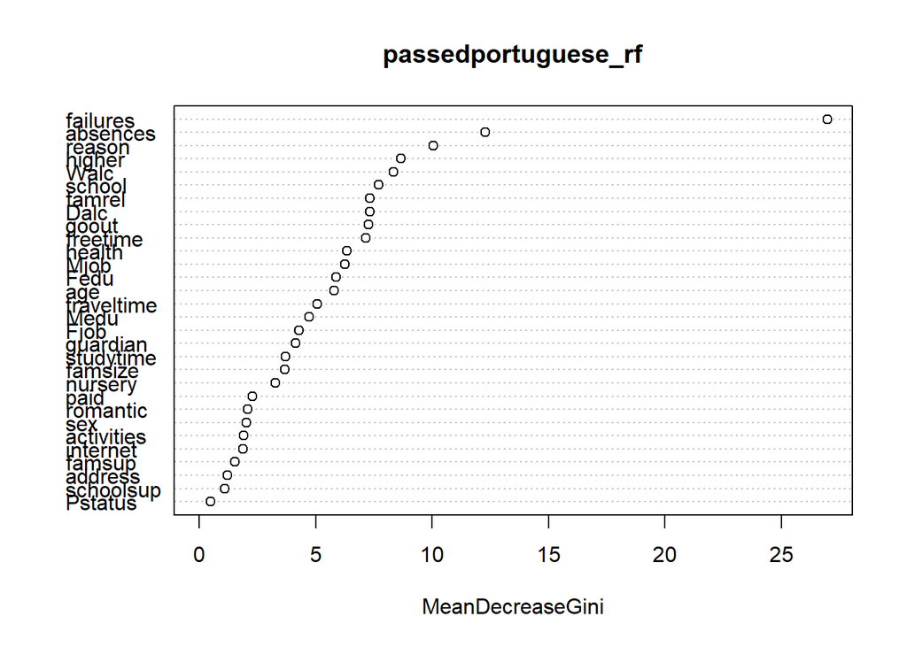

```r
varImpPlot(passedportuguese_rf)
```

```r
# Both absences and amount of past failed classes are influential variables.

passedmath_rf
```

```
##
## Call:
##  randomForest(formula = passed ~ ., data = newdata1.rf, mtry = pre,      ntree = 100)
##                Type of random forest: classification
##                      Number of trees: 100
## No. of variables tried at each split: 30
##
##         OOB estimate of  error rate: 29.11%
## Confusion matrix:
##     no yes class.error
## no  55  75   0.5769231
## yes 40 225   0.1509434
```

```r
passedportuguese_rf
```

```
##
## Call:
##  randomForest(formula = passed ~ ., data = newdata2.rf, mtry = pre,      ntree = 100)
##                Type of random forest: classification
##                      Number of trees: 100
## No. of variables tried at each split: 30
##
##         OOB estimate of  error rate: 16.18%
## Confusion matrix:
##     no yes class.error
## no  33  67  0.67000000
## yes 38 511  0.06921676
```

```r
## About 70% accuracy for Math, and 84% accuracy for Portuguese
```

Both failures and absences are significant predictors that affect whether a student passes in Math and Portuguese individually.  
Using Accuracy = 1-Out-of-bag error, we see that the Math model has an accuracy of around 70% and the Portuguese model with an accuracy of almost 84%.

```r
# Ridge Regression
library(glmnet)
library(caTools)
Mridge <- select_if(school1,is.numeric)
Pridge <- select_if(school2,is.numeric)

# Train & Testsets for Math students
Msample <- sample.split(Mridge, SplitRatio = 0.7)
Mtrain.RR <- na.omit(Mridge[Msample,])
Mtrain.X <- as.matrix(Mtrain.RR[,-c(14,15,16)])
Mtrain.Y <- Mtrain.RR[,16]

Mtest.RR <- na.omit(Mridge[-Msample,])
Mtest.X <- as.matrix(Mtest.RR[,-c(14,15,16)])
Mtest.Y <- Mtest.RR[,16]

# Train & Testsets for Portuguese students
Psample <- sample.split(Pridge, SplitRatio = 0.7)
Ptrain.RR <- na.omit(Pridge[Psample,])
Ptrain.X <- as.matrix(Ptrain.RR[,-c(14,15,16)])
Ptrain.Y <- Ptrain.RR[,16]

Ptest.RR <- na.omit(Pridge[-Psample,])
Ptest.X <- as.matrix(Ptest.RR[,-c(14,15,16)])
Ptest.Y <- Ptest.RR[,16]

schgrid <- 10^seq(-3,1,length=100)
```

#### Math Students

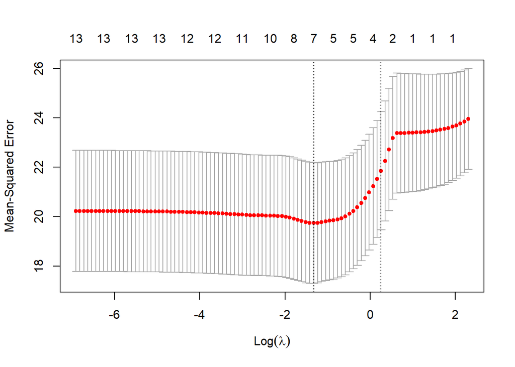

```r
# Math Students
M_ridge.m1 <- glmnet(Mtrain.X, Mtrain.Y, alpha = 1,intercept = FALSE, lambda = schgrid)

Mcv <- cv.glmnet(Mtrain.X, Mtrain.Y, alpha = 1,intercept = FALSE, lambda = schgrid)
plot(Mcv)
```

```r
goodlamda <- Mcv$lambda.min
goodlamda
```

```
## [1] 0.2656088
```

```r
M_ridge.pd <- predict(M_ridge.m1, s = goodlamda, newx = Mtest.X)
M_RMSE.ridge <- sqrt(mean((M_ridge.pd-Mtest.Y)^2))
M_RMSE.ridge
```

```
## [1] 4.299984
```

```r
M_glm <- glmnet(Mtrain.X, Mtrain.Y,alpha=1,lambda = schgrid)
M_ridge.coef <- predict(M_glm,type="coefficients",s=goodlamda)
M_ridge.coef
```

```
## 14 x 1 sparse Matrix of class "dgCMatrix"
##                       1
## (Intercept) 11.53516136
## age          .
## Medu         0.18812823
## Fedu         .
## traveltime  -0.40483960
## studytime    0.03831025
## failures    -1.66514181
## famrel       0.07732977
## freetime     .
## goout       -0.24090839
## Dalc         .
## Walc         .
## health      -0.06971458
## absences     .
```

#### Portuguese language students

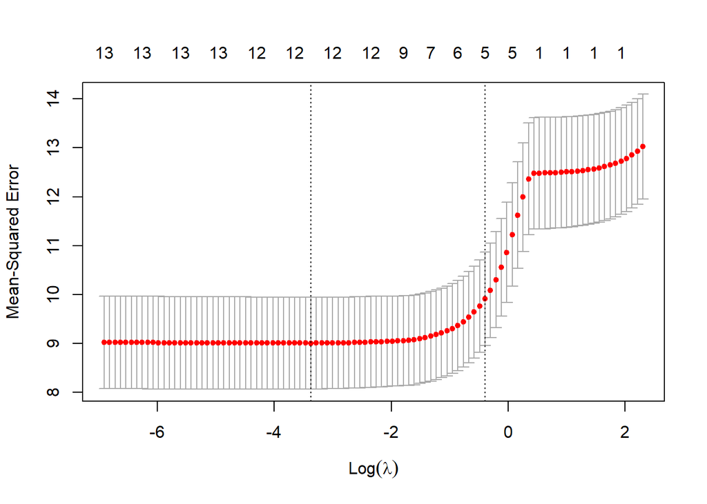

```r
# Portuguese
P_ridge.m1 <- glmnet(Ptrain.X, Ptrain.Y, alpha = 1,intercept = F, lambda = schgrid)

Pcv <- cv.glmnet(Ptrain.X, Ptrain.Y, alpha = 1,intercept = F, lambda = schgrid)
plot(Pcv)
```

```r
goodlamda2 <- Pcv$lambda.min
goodlamda2
```

```
## [1] 0.03430469
```

```r
P_ridge.pred <- predict(P_ridge.m1, s = goodlamda2, newx = Ptest.X)
P_RMSE.ridge <- sqrt(mean((P_ridge.pred-Ptest.Y)^2))
P_RMSE.ridge
```

```
## [1] 2.855098
```

```r
P_out <- glmnet(Ptrain.X, Ptrain.Y,alpha=1,lambda=schgrid)
P_ridge.coef <- predict(P_out,type="coefficients",s=goodlamda2)
P_ridge.coef
```

```
## 14 x 1 sparse Matrix of class "dgCMatrix"
##                         1
## (Intercept)  1.114769e+01
## age          .
## Medu         3.382646e-01
## Fedu         2.384303e-01
## traveltime  -7.754733e-05
## studytime    6.024020e-01
## failures    -1.556690e+00
## famrel       7.941203e-02
## freetime    -1.550735e-01
## goout       -4.601989e-02
## Dalc        -2.512736e-01
## Walc        -3.569721e-02
## health      -1.685151e-01
## absences    -2.475563e-02
```

For Portuguese students, the number of past failures is also the significant variable that will negatively affect their grade in Portuguese, followed by the amount of workday alcohol consumption.

A low RMSE value would indicate a good fit for the model. In this case, the RMSE for Portuguese is lower, hence a better fit.

### Conclusion

Also, across all models used, the most significant variable that influences the student’s grade for both courses would be the number of past failures.

Additionally, for math students, the number of times they went out with friends is also a slightly significant predictor.

Without the previous grades G1 and G2, it would be quite tough to make a prediction model for final grades with high accuracy since it is stated that there is a high correlation between G1, G2 and G3.  
Multicollinearity would be an issue since it reduces the statistical significance of an independent coefficient. (Springer,1997)

Lastly, comparing the RMSE output of the Linear and Ridge Regression, it is evident that the RMSE value for Ridge Regression is lower; hence the Ridge Regression model is a better fit (Chugh, 2020).

Ridge Regressions also solves data with multicollinearity problems well. However, the Random Forest algorithm would be a slightly better predictive model with its accuracy above 70%.

[[LinkedIn](https://www.linkedin.com/in/evantyy)] [[GitHub](https://github.com/evantyy/predict-student-perf)]

© Copyright. Evangeline Tan 2021.